# Report

Keliang Xu, Shuting Li, Tao He

3/2/2022

# 1 Abstract

Because of isotopes can enter animals’ bones by eating, through the comparisons of average levels of carbon and nitrogen isotopes from ancient animals bones in two sites of ancient Mexico, we can conclude about whether animals from two sites of ancient Mexico had similar diets.

Now briefly summarize our progress of this project.

1.) Data cleaning. Dropped 4 missing data and wrangled the data.

2.) Exploratory data analysis. Compared isotopes in different taxon and sites.

3.) Tests. Did Two-Sample T-tests and Mann Whitney U Test to compare the average isotopes’ levels between BAOX and PATT, two sites in ancient Mexico, for each kind of animals.

The conclusion we get is, at 0.01 significance level, all three isotope levels have non-significant difference between BAOX and PATT.

# 2 Introduction

## 2.1 Data Explanation

The variables of interest are “Taxa”, “Site” and “Carbon and Nitrogen Level”.

The “Taxa” includes four types of animals, which are turkey, cottontails, deer, and hare.

The “site” includes two sites, which are BAOX and PATT.

The “Carbon and Nitrogen level” includes three stable carbon and nitrogen isotopes from two closely related sites (BAOX and PATT) from the same area and period. “d13C_VPDB”, “ap_13C_VPDB” and “d15N_air”. These isotopes can enter bones by eating and reflect the isotopic values of food sources. The first two carbon isotopes tell us about the level of human-grown plants in the diet, such as maize (corn). Carbon isotopes from collagen are protein derived. Carbon isotopes from apatite (carbonate) reflect the whole diet. Nitrogen isotopes tell us about the protein in the diet.

## 2.2 Client’s Work

What our client has done:

1.) Use ANOVA to test for the differences between BAOX and PATT for each species.

2.) Examine boxplots and test just those groupings that look different.

## 2.3 Our Responsibility

1.) Check all client’s works, including the summary data table and box plots.

2.) Use statistical methods to show there is no significant difference in specific animals’ diets from BAOX and PATT, except cottontails.

# 3 EDA and Testing

## 3.1 Data Cleaning

Dropped 4 missing value, their IDs are MC381,MC389,MC393,MC76.

## 3.2 EDA

- Summary of Data:

The output is exactly same with client’s work.

```
## # A tibble: 24 x 9
## # Groups:   Taxa, Site [8]
##    Taxa       Site     variable       min median   mean    max    sd count
##    <chr>      <chr>    <fct>        <dbl>  <dbl>  <dbl>  <dbl> <dbl> <int>
##  1 Cottontail BAOX     d13C_VPDB   -20.5  -15.7  -16.3  -11.5   3.14     9
##  2 Cottontail BAOX     d15N_air      3.59   6.58   6.99  13.6   2.86     9
##  3 Cottontail BAOX     ap_13C_VPDB -12.8   -7.69  -8.71  -5.5   2.54     9
##  4 Cottontail Tlajinga d13C_VPDB   -21.1  -16.9  -16.7   -9.9   3.80     8
##  5 Cottontail Tlajinga d15N_air      2.77   3.88   4.30   7     1.53     8
##  6 Cottontail Tlajinga ap_13C_VPDB -13.3   -8.41  -9.25  -4.58  3.03     8
##  7 Deer       BAOX     d13C_VPDB   -20.6  -19.4  -18.8  -16.6   1.37     9
##  8 Deer       BAOX     d15N_air      3.5    4.97   5.27   6.91  1.22     9
##  9 Deer       BAOX     ap_13C_VPDB -12.8  -10.4  -10.1   -6.51  1.78     9
## 10 Deer       Tlajinga d13C_VPDB   -22.1  -18.9  -19.2  -15.8   2.47     9
## # ... with 14 more rows
```

In this plot, we compared specific isotopes level in 4 taxon. It showed the level of d15N_air is less diverse than other 2 isotopes.

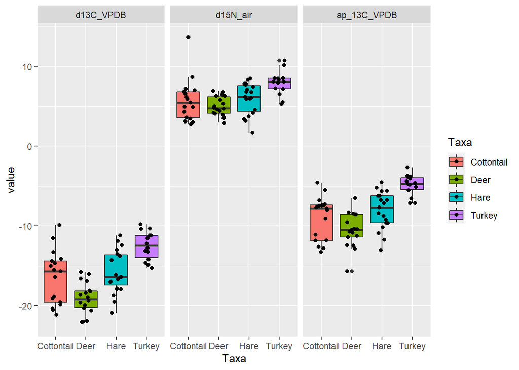

Then we compared isotopes in two sites for each kind of animals. The plot shows that the median level of d13C_VPDB and d15N_air in BAOX is higher than Tlajinga of cottontail. Similarly, the median level of d13C_VPDB and d15N_air of hare also show difference in the boxplot.

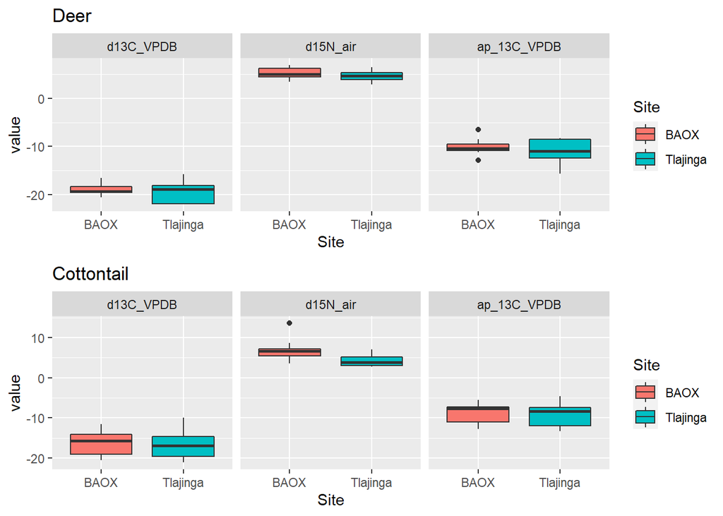

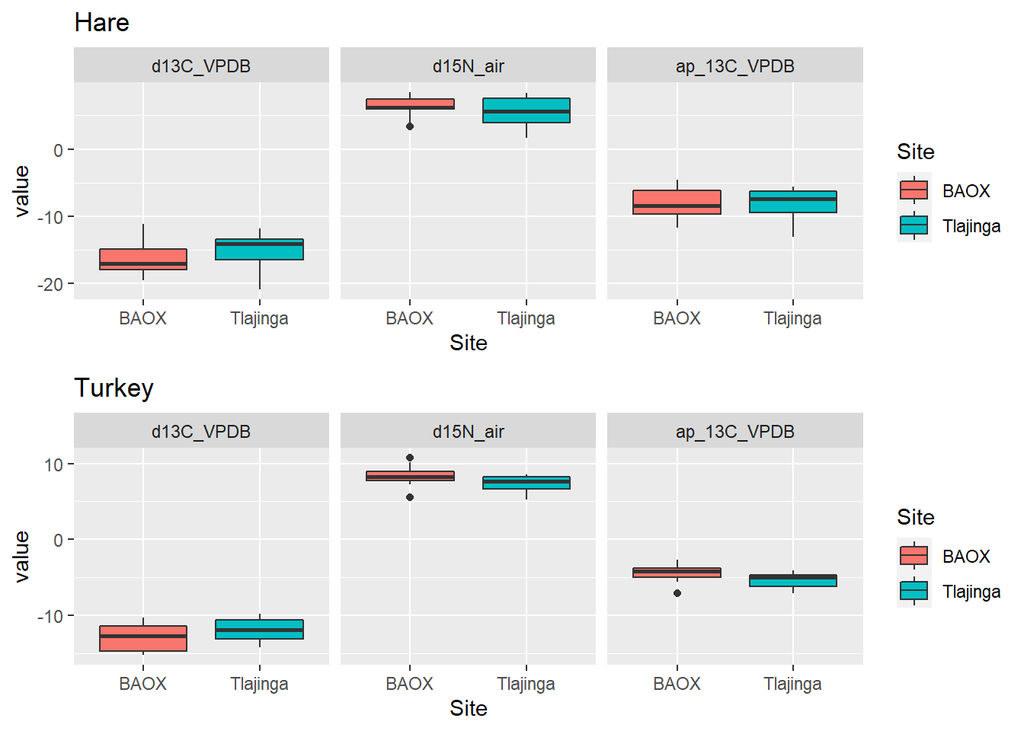

### Check Outlier

We found one outlier which is one of Cottontail d15N_air variable in BAOX. The outlier number is 13.6. The mean is 6.99. The sd is 2.86. 13.6 falls outside of $[mean-2sd , mean+2sd]=[1.27,12.71]$, so we believe it is a outlier.

The selected data set is as follows:

```
## [1]  5.47  3.59  4.89 13.60  8.65  6.16  6.58  6.80  7.18
```

According to client, we did not exclude this outlier from the data set. Therefore, all the data below include this outlier point.

## 3.2 Testing

### Two-Sample T-tests

After finding We plan to try some statistic test or some regression to compare the isotopes level in two sites more precisely. We would like to use the T-tests to find the difference of diets between two sites.

Firstly, we checked the normality.

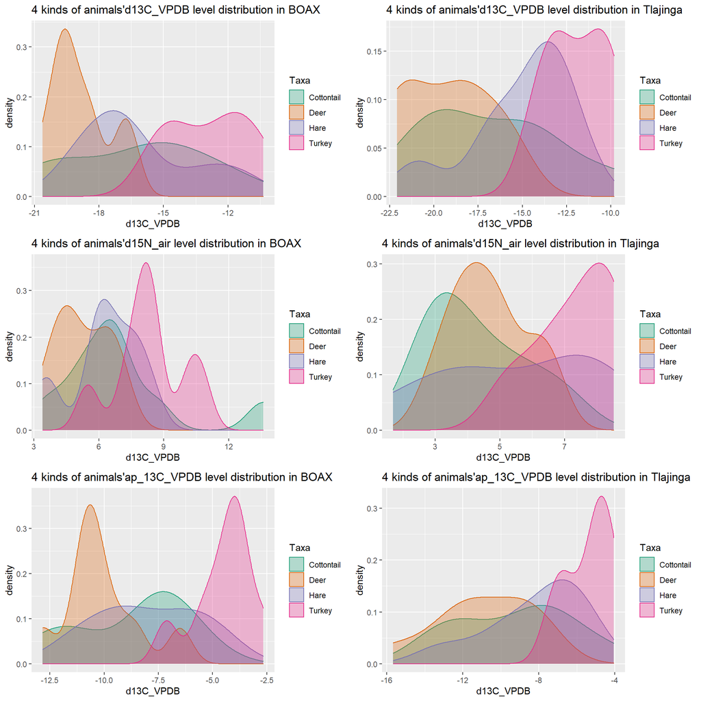

```r
gridExtra::grid.arrange(ggplot1, ggplot2, ggplot3, ggplot4, ggplot5, ggplot6)
```

It is difficult to see from the figures whether they follow the normal distribution, but comparing the distributions of the two places, most of them follow different distributions. It is reasonable since our sample size is too small.

Therefore, we also plot the Q-Q plots for checking the normality. The purpose of the quantile-quantile (QQ) plot is to show if two data sets come from the same distribution. Plotting the first data set’s quantiles along the x-axis and plotting the second data set’s quantiles along the y-axis is how the plot is constructed.

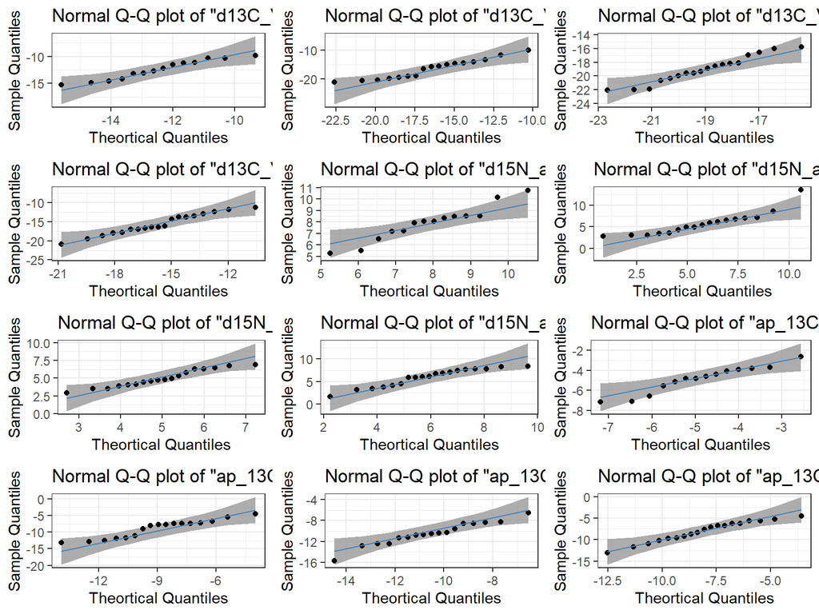

Expect “d15N_air” level in turkey groups, as almost all the points fall approximately along this reference line, we can assume normality to some extent.

After we checked the distribution of isotope levels for each animal in each space, since the sample size is too small to identify if they follow normal distributions. We decided to do some shapiro.test.

Shapiro.test is a test of normality. If the p-value from the result is greater than the significance level (e.g. 0.05), we can assume the normality. Then, from the results of shapiro.test(), we can regard all groups have the normal distribution at 95% confidence interval.

Since we have four different species and three isotope levels, we are supposed to have till 12 tests, which will exist the multiple testing problem. Therefore, we calculate the proper significant level so that the probability of observing at least one significant result due to chance remains below we desired significance level. The final significant level we set is 0.01. Moreover, We assume the null hypothesis is the isotope level for each species between two places are the same, while the alternative hypothesis is the isotope level for each species between two places are not the same.

## Mann Whitney U Test

### Mann Whitney U Test with R Package

We found that description of R function wilcox.test from R package stats: Performs one- and two-sample Wilcoxon tests on vectors of data; the latter is also known as ‘Mann-Whitney’ test. That was exactly what we need now. And the same as T-test, we use 99% confidence level and same null hypothesis to test.

We can carefully look at these results. Since these p-values are not less than 0.01, we fail to reject the null hypothesis.

### Check Mann-Whitney U Test with theory

We are concerned that small data size (about n=10) may affect the accuracy of the R package function. Therefore, we wrote a program to test the data in full accordance with the Mann-Whitney U Test theory with a significance level of .01. In the program, if the return value is True we can reject the null hypothesis, and if the return value is False, we fail to reject the null hypothesis.

Based on all return values being false, we fail to reject the null hypothesis. Since we failed to reject the null hypothesis, we do not have sufficient evidence to say that the “Carbon and Nitrogen Level” of each animals in two sites are different.

# 4 Discussion

There exists an outlier point in the data set.

# 5 Conclusion

1.) We checked all her works, including the summary data table and box plots.

2.) Use two methods - two samples t test and Mann-Whitney U Test, to show there is no significant difference in specific animals’ diets from BAOX and PATT.

# Appendix

## Test code

Two-Sample T-tests are as followings:

### “d13C_VPDB” level

```r
# Assumption
# H0 : v1  = v2
# Ha : v1 != v2
```

```
##
##  Shapiro-Wilk normality test
##
## data:  value[Site == "BAOX"]
## W = 0.9237, p-value = 0.4606
```

```
##
##  Shapiro-Wilk normality test
##
## data:  value[Site == "Tlajinga"]
## W = 0.94538, p-value = 0.7027
```

```
##
##  Two Sample t-test
##
## data:  value by Site
## t = -1.0102, df = 12, p-value = 0.3323
## alternative hypothesis: true difference in means between group BAOX and group Tlajinga is not equal to 0
## 99 percent confidence interval:
##  -3.968245  1.995745
## sample estimates:
##     mean in group BAOX mean in group Tlajinga
##              -12.89625              -11.91000
```

```
##
##  Shapiro-Wilk normality test
##
## data:  value[Site == "BAOX"]
## W = 0.94142, p-value = 0.5969
```

```
##
##  Shapiro-Wilk normality test
##
## data:  value[Site == "Tlajinga"]
## W = 0.91546, p-value = 0.3941
```

```
##
##  Two Sample t-test
##
## data:  value by Site
## t = 0.23657, df = 15, p-value = 0.8162
## alternative hypothesis: true difference in means between group BAOX and group Tlajinga is not equal to 0
## 99 percent confidence interval:
##  -4.558434  5.354267
## sample estimates:
##     mean in group BAOX mean in group Tlajinga
##              -16.26333              -16.66125
```

```
##
##  Shapiro-Wilk normality test
##
## data:  value[Site == "BAOX"]
## W = 0.9199, p-value = 0.3914
```

```
##
##  Shapiro-Wilk normality test
##
## data:  value[Site == "Tlajinga"]
## W = 0.89371, p-value = 0.2177
```

```
##
##  Two Sample t-test
##
## data:  value by Site
## t = 0.44023, df = 16, p-value = 0.6657
## alternative hypothesis: true difference in means between group BAOX and group Tlajinga is not equal to 0
## 99 percent confidence interval:
##  -2.335259  3.164148
## sample estimates:
##     mean in group BAOX mean in group Tlajinga
##              -18.83333              -19.24778
```

```
##
##  Shapiro-Wilk normality test
##
## data:  value[Site == "BAOX"]
## W = 0.91386, p-value = 0.2707
```

```
##
##  Shapiro-Wilk normality test
##
## data:  value[Site == "Tlajinga"]
## W = 0.89208, p-value = 0.2447
```

```
##
##  Two Sample t-test
##
## data:  value by Site
## t = -0.86338, df = 17, p-value = 0.3999
## alternative hypothesis: true difference in means between group BAOX and group Tlajinga is not equal to 0
## 99 percent confidence interval:
##  -4.795489  2.594125
## sample estimates:
##     mean in group BAOX mean in group Tlajinga
##              -16.15818              -15.05750
```

### “d15N_air” level

```
##
##  Shapiro-Wilk normality test
##
## data:  value[Site == "BAOX"]
## W = 0.95604, p-value = 0.7717
```

```
##
##  Shapiro-Wilk normality test
##
## data:  value[Site == "Tlajinga"]
## W = 0.91253, p-value = 0.4532
```

```
##
##  Two Sample t-test
##
## data:  value by Site
## t = 1.261, df = 12, p-value = 0.2313
## alternative hypothesis: true difference in means between group BAOX and group Tlajinga is not equal to 0
## 99 percent confidence interval:
##  -1.439417  3.463583
## sample estimates:
##     mean in group BAOX mean in group Tlajinga
##               8.323750               7.311667
```

```
##
##  Shapiro-Wilk normality test
##
## data:  value[Site == "BAOX"]
## W = 0.85937, p-value = 0.09437
```

```
##
##  Shapiro-Wilk normality test
##
## data:  value[Site == "Tlajinga"]
## W = 0.89679, p-value = 0.2703
```

```
##
##  Two Sample t-test
##
## data:  value by Site
## t = 2.3623, df = 15, p-value = 0.0321
## alternative hypothesis: true difference in means between group BAOX and group Tlajinga is not equal to 0
## 99 percent confidence interval:
##  -0.6644531  6.0366753
## sample estimates:
##     mean in group BAOX mean in group Tlajinga
##               6.991111               4.305000
```

```
##
##  Shapiro-Wilk normality test
##
## data:  value[Site == "BAOX"]
## W = 0.93783, p-value = 0.5592
```

```
##
##  Shapiro-Wilk normality test
##
## data:  value[Site == "Tlajinga"]
## W = 0.9573, p-value = 0.7696
```

```
##
##  Two Sample t-test
##
## data:  value by Site
## t = 1.0472, df = 16, p-value = 0.3106
## alternative hypothesis: true difference in means between group BAOX and group Tlajinga is not equal to 0
## 99 percent confidence interval:
##  -1.067488  2.260822
## sample estimates:
##     mean in group BAOX mean in group Tlajinga
##               5.270000               4.673333
```

```
##
##  Shapiro-Wilk normality test
##
## data:  value[Site == "BAOX"]
## W = 0.92055, p-value = 0.3232
```

```
##
##  Shapiro-Wilk normality test
##
## data:  value[Site == "Tlajinga"]
## W = 0.92163, p-value = 0.4432
```

```
##
##  Two Sample t-test
##
## data:  value by Site
## t = 0.86085, df = 17, p-value = 0.4013
## alternative hypothesis: true difference in means between group BAOX and group Tlajinga is not equal to 0
## 99 percent confidence interval:
##  -1.872939  3.455666
## sample estimates:
##     mean in group BAOX mean in group Tlajinga
##               6.276364               5.485000
```

### “ap_13C_VPDB” level

```
##
##  Shapiro-Wilk normality test
##
## data:  value[Site == "BAOX"]
## W = 0.9376, p-value = 0.5876
```

```
##
##  Shapiro-Wilk normality test
##
## data:  value[Site == "Tlajinga"]
## W = 0.90418, p-value = 0.3992
```

```
##
##  Two Sample t-test
##
## data:  value by Site
## t = 1.2818, df = 12, p-value = 0.2241
## alternative hypothesis: true difference in means between group BAOX and group Tlajinga is not equal to 0
## 99 percent confidence interval:
##  -1.243518  3.041852
## sample estimates:
##     mean in group BAOX mean in group Tlajinga
##              -4.487500              -5.386667
```

```
##
##  Shapiro-Wilk normality test
##
## data:  value[Site == "BAOX"]
## W = 0.88268, p-value = 0.1675
```

```
##
##  Shapiro-Wilk normality test
##
## data:  value[Site == "Tlajinga"]
## W = 0.9259, p-value = 0.4795
```

```
##
##  Two Sample t-test
##
## data:  value by Site
## t = 0.39896, df = 15, p-value = 0.6955
## alternative hypothesis: true difference in means between group BAOX and group Tlajinga is not equal to 0
## 99 percent confidence interval:
##  -3.439573  4.516795
## sample estimates:
##     mean in group BAOX mean in group Tlajinga
##              -8.708889              -9.247500
```

```
##
##  Shapiro-Wilk normality test
##
## data:  value[Site == "BAOX"]
## W = 0.93596, p-value = 0.54
```

```
##
##  Shapiro-Wilk normality test
##
## data:  value[Site == "Tlajinga"]
## W = 0.90374, p-value = 0.3121
```

```
##
##  Two Sample t-test
##
## data:  value by Site
## t = 0.79213, df = 15, p-value = 0.4406
## alternative hypothesis: true difference in means between group BAOX and group Tlajinga is not equal to 0
## 99 percent confidence interval:
##  -2.291227  3.975950
## sample estimates:
##     mean in group BAOX mean in group Tlajinga
##              -10.11889              -10.96125
```

```
##
##  Shapiro-Wilk normality test
##
## data:  value[Site == "BAOX"]
## W = 0.95748, p-value = 0.7399
```

```
##
##  Shapiro-Wilk normality test
##
## data:  value[Site == "Tlajinga"]
## W = 0.8977, p-value = 0.2754
```

```
##
##  Two Sample t-test
##
## data:  value by Site
## t = 0.15129, df = 17, p-value = 0.8815
## alternative hypothesis: true difference in means between group BAOX and group Tlajinga is not equal to 0
## 99 percent confidence interval:
##  -3.117610  3.461019
## sample estimates:
##     mean in group BAOX mean in group Tlajinga
##              -7.984545              -8.156250
```

### Mann Whitney U Test with R Package

Mann-Whitney U Test for deer.

```
##
##  Wilcoxon rank sum exact test
##
## data:  value by Site
## W = 43, p-value = 0.8633
## alternative hypothesis: true location shift is not equal to 0
```

```
##
##  Wilcoxon rank sum exact test
##
## data:  value by Site
## W = 41, p-value = 0.673
## alternative hypothesis: true location shift is not equal to 0
```

```
##
##  Wilcoxon rank sum test with continuity correction
##
## data:  value by Site
## W = 51.5, p-value = 0.3536
## alternative hypothesis: true location shift is not equal to 0
```

Mann-Whitney U Test for Cottontail.

```
##
##  Wilcoxon rank sum exact test
##
## data:  value by Site
## W = 38, p-value = 0.8884
## alternative hypothesis: true location shift is not equal to 0
```

```
##
##  Wilcoxon rank sum exact test
##
## data:  value by Site
## W = 43, p-value = 0.5414
## alternative hypothesis: true location shift is not equal to 0
```

```
##
##  Wilcoxon rank sum exact test
##
## data:  value by Site
## W = 60, p-value = 0.02065
## alternative hypothesis: true location shift is not equal to 0
```

Mann-Whitney U Test for Hare.

```
##
##  Wilcoxon rank sum exact test
##
## data:  value by Site
## W = 32, p-value = 0.3511
## alternative hypothesis: true location shift is not equal to 0
```

```
##
##  Wilcoxon rank sum test with continuity correction
##
## data:  value by Site
## W = 45, p-value = 0.9671
## alternative hypothesis: true location shift is not equal to 0
```

```
##
##  Wilcoxon rank sum exact test
##
## data:  value by Site
## W = 50, p-value = 0.6574
## alternative hypothesis: true location shift is not equal to 0
```

Mann-Whitney U Test for Turkey.

```
##
##  Wilcoxon rank sum test with continuity correction
##
## data:  value by Site
## W = 15.5, p-value = 0.3012
## alternative hypothesis: true location shift is not equal to 0
```

```
##
##  Wilcoxon rank sum exact test
##
## data:  value by Site
## W = 36, p-value = 0.1419
## alternative hypothesis: true location shift is not equal to 0
```

```
##
##  Wilcoxon rank sum test with continuity correction
##
## data:  value by Site
## W = 32.5, p-value = 0.3012
## alternative hypothesis: true location shift is not equal to 0
```

### Check Mann-Whitney U Test with theory

Mann-Whitney U Test for deer.

```
## [1] "d13C_VPDB:"
```

```
## [1] FALSE
```

```
## [1] "d15N_air:"
```

```
## [1] FALSE
```

```
## [1] "ap_13C_VPDB:"
```

```
## [1] FALSE
```

Mann-Whitney U Test for Cottontail.

```
## [1] "d13C_VPDB:"
```

```
## [1] FALSE
```

```
## [1] "d15N_air:"
```

```
## [1] FALSE
```

```
## [1] "ap_13C_VPDB:"
```

```
## [1] FALSE
```

Mann-Whitney U Test for Hare.

```
## [1] "d13C_VPDB:"
```

```
## [1] FALSE
```

```
## [1] "d15N_air:"
```

```
## [1] FALSE
```

```
## [1] "ap_13C_VPDB:"
```

```
## [1] FALSE
```

Mann-Whitney U Test for Turkey.

```
## [1] "d13C_VPDB:"
```

```
## [1] FALSE
```

```
## [1] "d15N_air:"
```

```
## [1] FALSE
```

```
## [1] "ap_13C_VPDB:"
```

```
## [1] FALSE
```

## Resource

**multiple testing**

Megan Goldman, 2008, [Statistics for Bioinformatics](https://www.stat.berkeley.edu/~mgoldman/Section0402.pdf)

**Mann-Whitney U Test**

[Mann-Whitney U Test Theory](https://www.statology.org/mann-whitney-u-test/)

[Mann-Whitney U Test table](https://www.statology.org/mann-whitney-u-table/)